# DEAKit Report - Effect of PCR in gene expression

2018-06-20

### Introduction

The analysis protocol is based on the sequential execution of the following steps:

1. Load RCC files. Build counts matrix
2. Data normaliZation
3. Differential expression analysis
4. Pathway analysis

### Execution

#### Load the data

Get a matrix with the raw counts from the set of samples we want to analyse.

We are working with 54 samples. We might need more samples to obtain significant results.

#### QC Control an normalisation.

We monitor some QC aspects and normalise the data according to several criteria.

##### Imaging QC

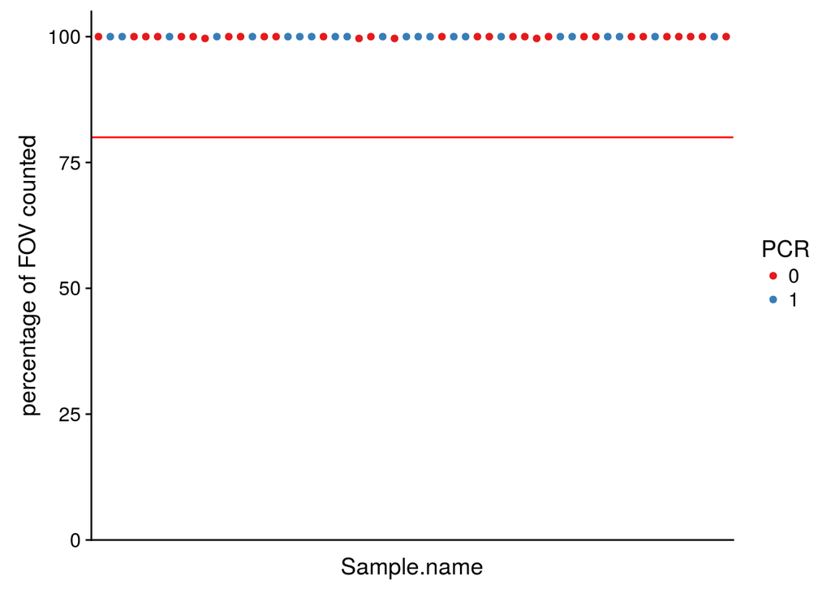

```r
# Field of View (FOV) Plots
plotFOV(eset = eset, metadata = metadata, fov.threshold = FOV.THRESHOLD,
        comparison.key = key.label, legend.label = LABEL.OF.INTEREST)
```

##### Binding density QC

Due to the nature of the nCounter technology, analysis of some samples may produce too many or too few probes to be accurately counted by the Digital Analyzer. When too many probes are present, the Digital Analyzer is not able to distinguish each and every probe present in the lane. When too few fluorescent species are present, the Digital Analyzer may have difficulty focusing on the lane surface. Therefore, a measurement of mean binding density (spots per square micron) is provided with each lane scanned. The linear range of counting extends from 0.05 to 2.25 spots per square micron for assays run on an nCounter MAX or FLEX system. The range is 0.05 to 1.18 spots per square micron for assays run on the nCounter SPRINT system. (see nSolver User Manual).

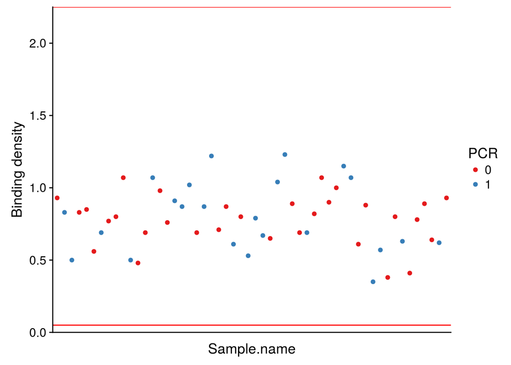

```r
# Binding Density (BD) Plots
plotBD(eset = eset, metadata = metadata, y.thresholds = BD.THRESHOLDS,
       comparison.key = key.label, legend.label = LABEL.OF.INTEREST)
```

##### Positive Controls

Check the expression of the positive controls. The positive genes follow the expeted pattern of expresssion.

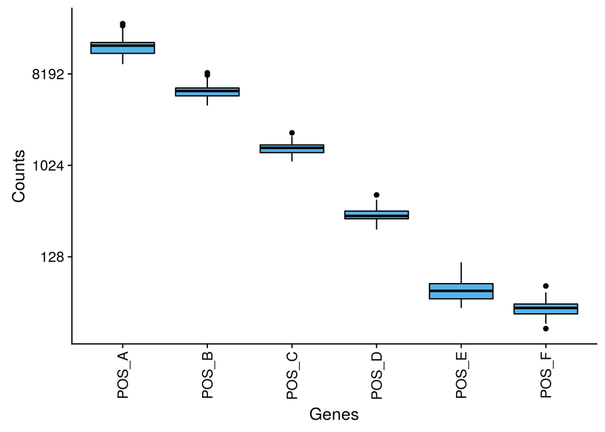

```r
# Positive Controls
boxplot.expr(eset,is.positive)
```

Check the expression of the negative controls

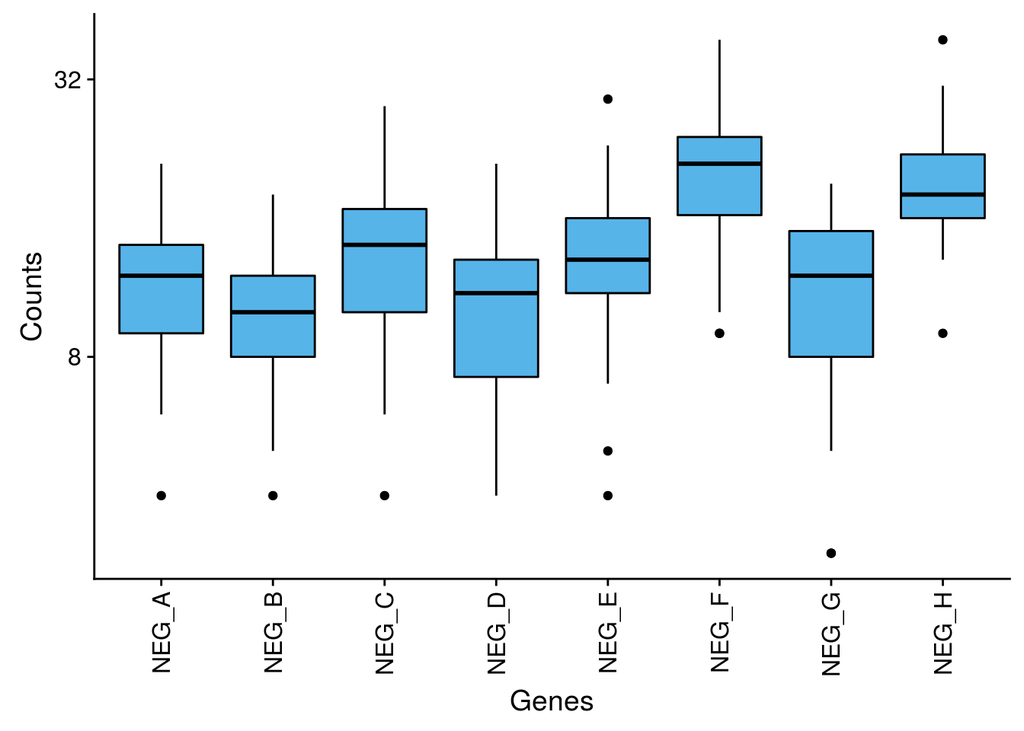

```r
# Negative Controls
boxplot.expr(eset,is.negative)
```

##### Noise Threshold

We establish a noise threshold. This threshold is based on the mean and standard deviation of counts of the negative control genes and represents the background noise. We define it as the mean expression of the negative genes counts + 2 times the standard deviation.

```r
# Noise Threshold
lodcounts <- extract.pred(eset, is.negative)
lod <- mean(lodcounts$count) + 2 * sd(lodcounts$count)
```

##### Housekeeping genes

Expression of each housekeeping genes in all samples. The line in red represents the noise threshold.

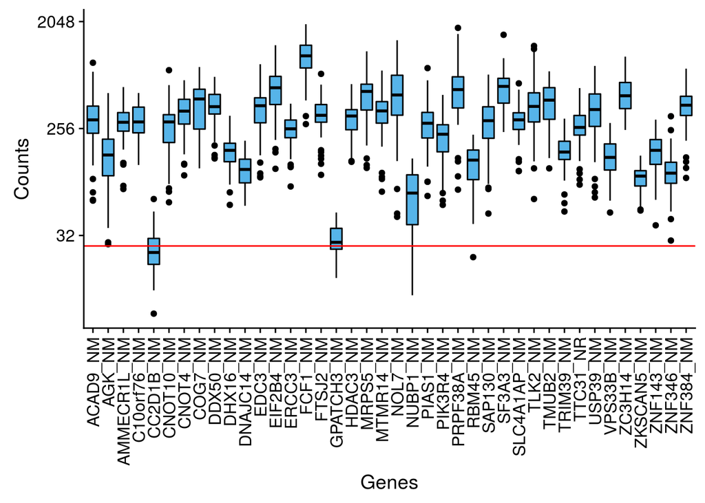

```r
# Housekeeping Genes
housekeeping.boxplot<-boxplot.expr(eset,is.housekeeping)
housekeeping.boxplot+geom_hline(yintercept = (lod),colour="red")
```

##### Expression of all the housekeeping genes in each sample.

We plot the mean expression of all the housekeeping genes in each sample. We can obverve that some sample have overall low expression for the housekeeping genes, but all are above the noise threshold.

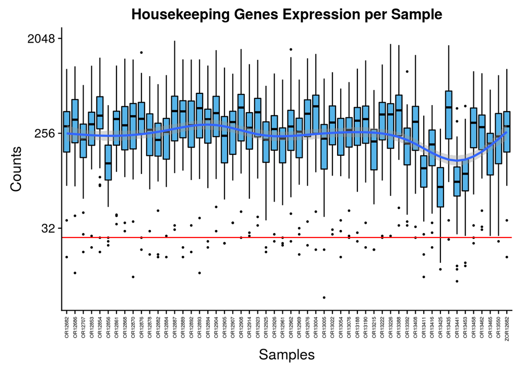

```r
# Expression of all the housekeeping genes in each sample
housekeeping.condition.boxplot+geom_hline(yintercept = (lod),colour="red")
```

##### General expression

Expression of all genes (Endogenous + Housekeeping).

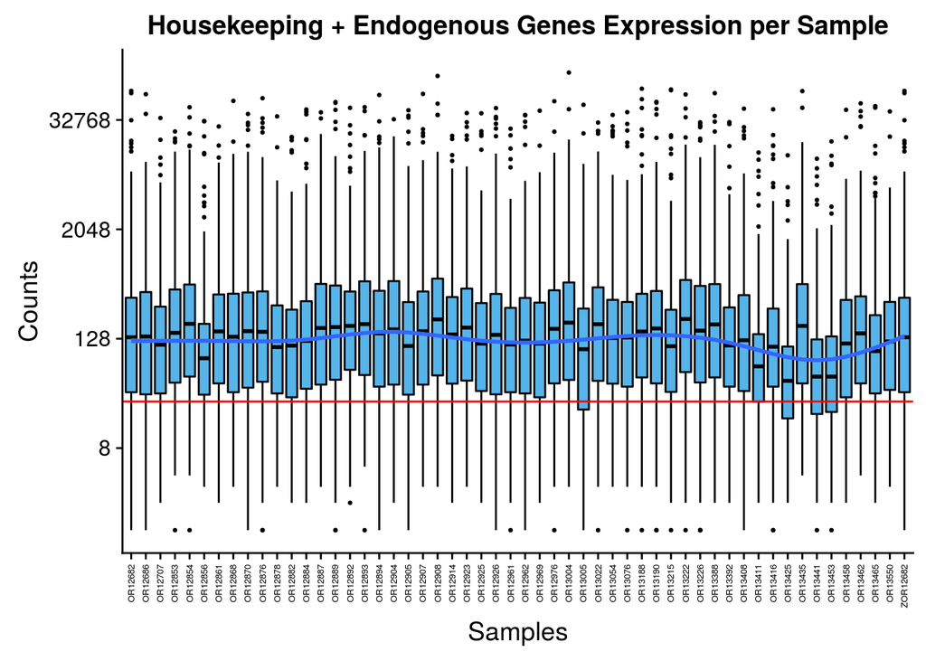

```r
# Expression of multiple condition genes in each sample
endogenous.housekeeping.condition.boxplot+geom_hline(yintercept = (lod),colour="red")
```

#### Normalization

##### Positive Normalization

We perform a normalization using the expression of the positive genes. This attempts to normalize for technical noise across the samples

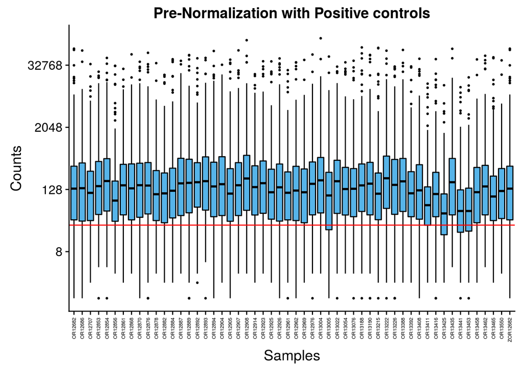

```r
pre.normalization.boxplot + geom_hline(yintercept = lod,colour="red")
```

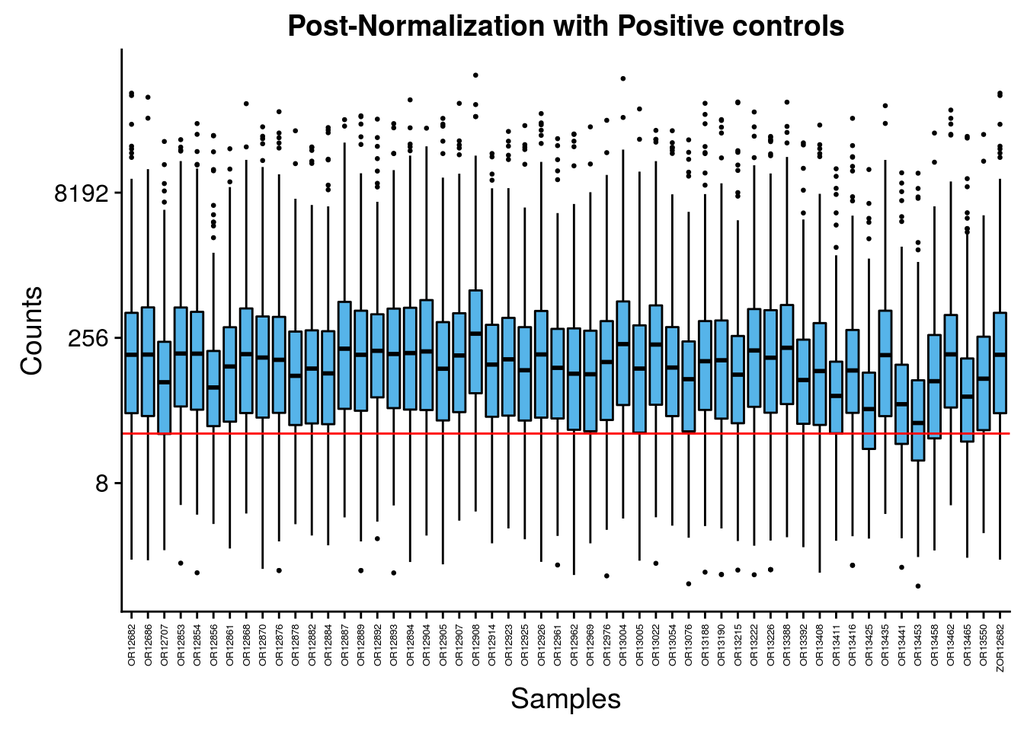

```r
post.normalization.boxplot + geom_hline(yintercept = lod,colour="red")
```

We can see that this normalisation doesn’t make the samples look better.